# MarioKart 64 World Records

Gary Lu

7/28/2021

Data is from Thomas Mock (2021). Tidy Tuesday: A weekly data project aimed at the R ecosystem. https://github.com/rfordatascience/tidytuesday. https://github.com/rfordatascience/tidytuesday/blob/master/data/2021/2021-05-25/readme.md

The data this week comes from Mario Kart World Records and contains world records for the classic (if you’re a 90’s kid) racing game on the Nintendo 64.

This [video](https://www.youtube.com/watch?v=D6cpa-TvKn8&ab_channel=SummoningSalt) talks about the history of Mario Kart 64 World Records in greater detail. Despite it’s release back in 1996 (1997 in Europe and North America), it is still actiely played by many and new world records are achieved every month.

The game consists of 16 individual tracks and world records can be achieved for the fastest single lap or the fastest completed race (three laps). Also, through the years, players discovered shortcuts in many of the tracks. Fortunately, shortcut and non-shortcut world records are listed separately.

Furthermore, the Nintendo 64 was released for NTSC- and PAL-systems. On PAL-systems, the game runs a little slower. All times in this dataset are PAL-times, but they can be converted back to NTSC-times.

Credit: [Benedikt Claus](https://github.com/benediktclaus)

```
## --- Compiling #TidyTuesday Information for 2021-05-25 ----
```

```
## --- There are 2 files available ---
```

```
## --- Starting Download ---
```

```
## --- Download complete ---
```

### Sample questions from the readme

- How did the world records develop over time?
- Which track is the fastest?
- For which track did the world record improve the most?
- For how many tracks have shortcuts been discovered?
- When were shortcuts discovered?
- On which track does the shortcut save the most time?
- Which is the longest standing world record?
- Who is the player with the most world records?
- Who are recent players?

> How did the world records develop over time?

```r
course_records <- records %>% filter(type == "Three Lap")

lap_records <- records %>% filter(type == "Single Lap")
```

> Which track is the fastest?

Data will be split by 3 lap and 1 lap records

```r
course_records %>%
  group_by(track, shortcut) %>%
  summarise(mean_time = mean(time),
            median_time = median(time)) %>%
  arrange(mean_time)
```

```
## # A tibble: 28 x 4
## # Groups:   track [16]
##    track                 shortcut mean_time median_time
##    <chr>                 <chr>        <dbl>       <dbl>
##  1 Wario Stadium         Yes           22.6        15.4
##  2 D.K.'s Jungle Parkway Yes           24.8        24.4
##  3 Frappe Snowland       Yes           26.0        26.1
##  4 Yoshi Valley          Yes           36.1        33.6
##  5 Mario Raceway         Yes           62.2        61.9
##  6 Choco Mountain        Yes           68.5        78.5
##  7 Luigi Raceway         Yes           77.3        91.6
##  8 Toad's Turnpike       Yes           80.8       109.
##  9 Moo Moo Farm          No            88.4        88.0
## 10 Mario Raceway         No            88.9        88.3
## # ... with 18 more rows
```

The shortcut column indicates if a shortcut was used or not in the WR attempt, and as you can see, it makes a big difference in most stages

Mario Raceway is the first track to show up twice when grouped by track then shortcut which indicates that it is, on average, the fastest track for speedrunners to complete.

Rainbow Road takes the longest out of all tracks to complete regardless of a shortcut (it is notorious for being the most difficult track in all Mario Kart games)

##### *Looking at which tracks are most dependent on shortcuts*

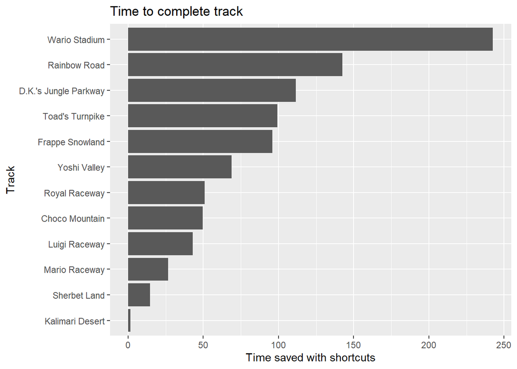

```r
course_records %>%
  group_by(track, shortcut) %>%
  summarise(mean_time = mean(time),
            median_time = median(time)) %>%
  mutate(shortcutdiff = coalesce(mean_time - lag(mean_time)) * -1) %>%   # Multiply by -1 to remove negative.
  arrange(desc(track)) %>%
  filter(!is.na(shortcutdiff)) %>%
  ggplot()+
  geom_col(aes(x = fct_reorder(track, shortcutdiff), y = shortcutdiff))+
  coord_flip()+
  labs(x = "Track",
       y = "Time saved with shortcuts",
       title = "Time to complete track")
```

It seems learning the shortcut on Wario Stadium is one of the most important shortcuts to learn as it saves nearly 4 minutes of time (something to consider if you want to make your friends angry!)

Rainbow Road on average saves the 2nd most time with the shortcut, but still makes it one of the longer tracks to complete.

> For which track did the world record improve the most?

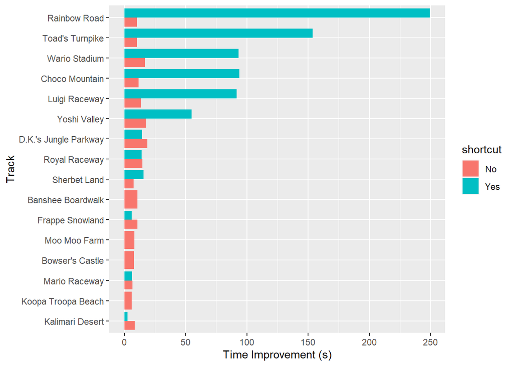

```r
course_records_ntsc <- course_records %>% filter(system_played == "NTSC")

course_records_ntsc %>%
  group_by(track, shortcut) %>%
  summarise(record_diff = max(time) - min(time)) %>%
  arrange(record_diff %>% desc()) %>%
  ggplot(aes(x = fct_reorder(track, record_diff), y = record_diff, fill = shortcut))+
  geom_col(position = "dodge")+
  coord_flip()+
  labs(x = "Track",
       y = "Time Improvement (s)")
```

Counting shortcuts, Rainbow Road has seen the most improvement in record times, With DK Jungle Parkway showing the most improvement without shortcuts

> When were shortcuts discovered?

```r
shortcuts <- records %>% filter(shortcut == "Yes")

shortcuts %>%
  group_by(track) %>%
  arrange(date) %>%
  summarise(date_found = first(date))
```

```
## # A tibble: 12 x 2
##    track                 date_found
##    <chr>                 <date>
##  1 Choco Mountain        1997-03-10
##  2 D.K.'s Jungle Parkway 1997-03-10
##  3 Frappe Snowland       1997-03-10
##  4 Kalimari Desert       1997-03-10
##  5 Luigi Raceway         1997-02-16
##  6 Mario Raceway         1997-03-10
##  7 Rainbow Road          1997-03-07
##  8 Royal Raceway         1997-03-10
##  9 Sherbet Land          1997-03-10
## 10 Toad's Turnpike       1997-03-10
## 11 Wario Stadium         1997-03-10
## 12 Yoshi Valley          1997-03-07
```

> On which track does the shortcut save the most time?

Answered above

> Which is the longest standing world record?

```r
records %>%
  group_by(system_played, track, type) %>%
  arrange(record_duration %>% desc()) %>%
  head(10)
```

```
## # A tibble: 10 x 9
## # Groups:   system_played, track, type [6]
##    track      type   shortcut player  system_played date       time_period  time
##    <chr>      <chr>  <chr>    <chr>   <chr>         <date>     <chr>       <dbl>
##  1 Yoshi Val~ Three~ Yes      Alex G  PAL           2010-11-27 33.39S       33.4
##  2 Yoshi Val~ Three~ Yes      VAJ     PAL           2012-06-05 33.39S       33.4
##  3 Koopa Tro~ Singl~ No       MJ      PAL           2004-09-06 30.92S       30.9
##  4 Royal Rac~ Three~ No       Troy    NTSC          2004-09-03 2M 52.29S   172.
##  5 Luigi Rac~ Singl~ No       MJ      PAL           2003-10-05 37.69S       37.7
##  6 Luigi Rac~ Singl~ Yes      MJ      PAL           2003-10-05 37.69S       37.7
##  7 Choco Mou~ Three~ Yes      VAJ     PAL           2007-05-08 1M 12.5S     72.5
##  8 Yoshi Val~ Three~ Yes      Greg I  PAL           2013-07-31 33.39S       33.4
##  9 Yoshi Val~ Singl~ No       Michae~ NTSC          2005-06-29 31.48S       31.5
## 10 Yoshi Val~ Singl~ Yes      Michae~ NTSC          2005-06-29 31.48S       31.5
## # ... with 1 more variable: record_duration <dbl>
```

> Who is the player with the most world records?

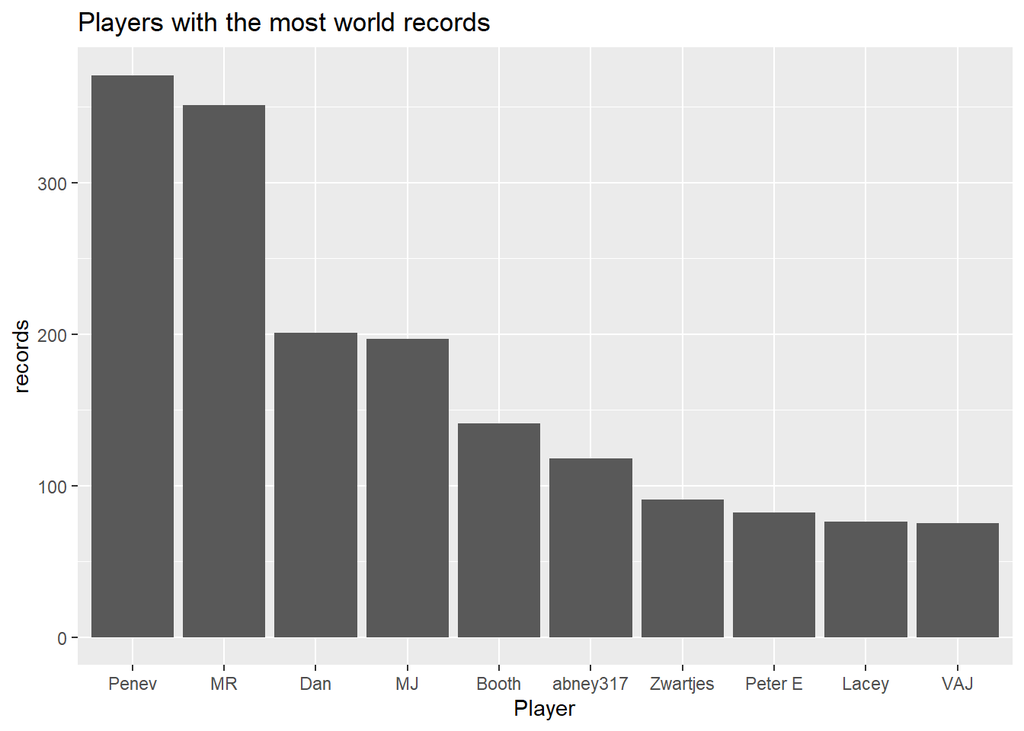

```r
players <- records %>%
            group_by(player)

players %>%
  summarise(records = n()) %>%
  arrange(records %>%  desc()) %>%
  head(10) %>%
  ggplot(aes(x = fct_reorder(player,-records), records))+
  geom_col()+
  labs(title = "Players with the most world records",
       x = "Player")
```

> Breaking it down per year

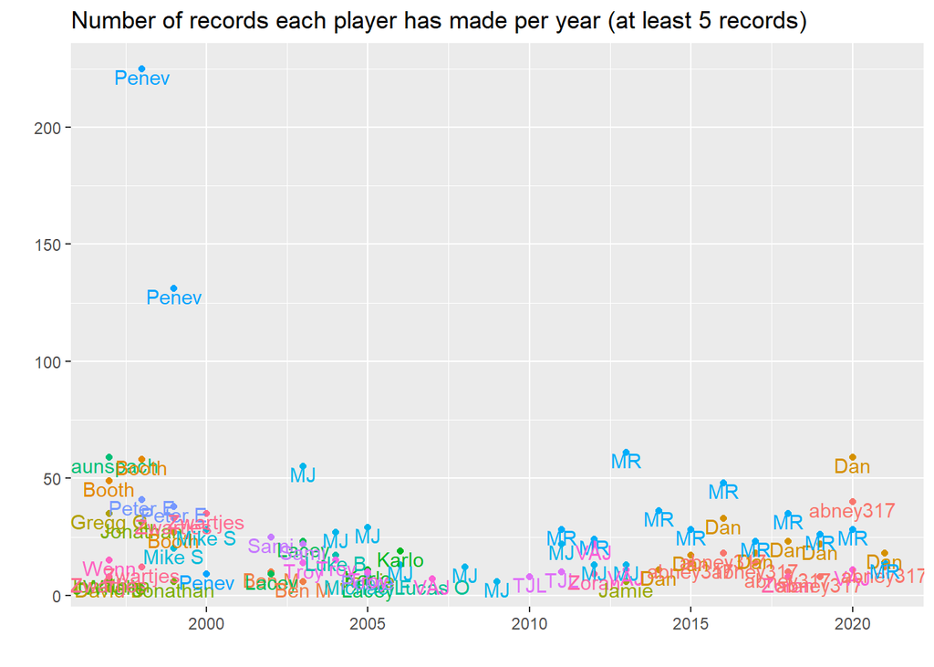

```r
players %>%
  ungroup() %>%
  mutate(year = year(date)) %>%
  group_by(year) %>%
  mutate(n = n()) %>%
  group_by(year, player) %>%
  summarise(n = n()) %>%
  filter(n > 5) %>%
  ggplot(aes(x = year, n, color = player, label = player))+
  geom_point()+
  geom_text(vjust = 1)+
  labs(title = "Number of records each player has made per year (at least 5 records)",
       y = "",
       x = "")+
  theme(legend.position = "none")
```

We see that players like Penev and MJ had the most records for the first years of playing. MR, DAN, and abney317 had the most records during the later years In MR’s case, it’s more impressive since he has the 2nd most overall records

> Can we determine a GOAT? (Greatest of all time)

If we are to determine a GOAT in a game that has been played for 20 years, we need to determine what makes the GOAT? Some ideas are * Fastest cumulative time over all stages + The problem with this is that not all players will have a record on all stages * Total record duration (i.e. longest unbroken records)

> Fastest cumulative time over all stages

I will break this down into 3 lap and 1 lap since techniques can vary and further broken down into whether shortcuts were used or not

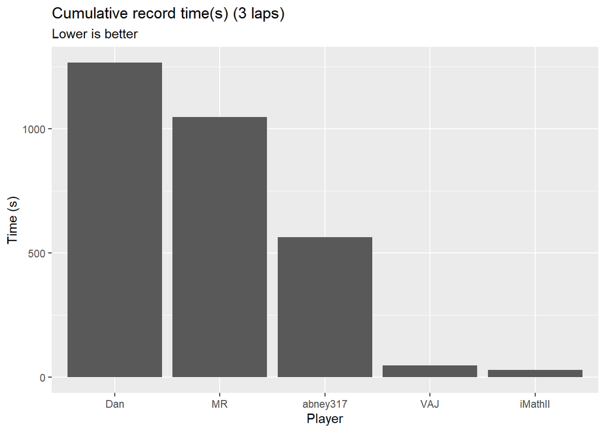

```r
course_records %>%
  group_by(track, shortcut) %>%
  slice_min(time) %>%
  group_by(player) %>%
  summarise(sum_time_s = sum(time)) %>%
  ggplot(aes(x = fct_reorder(player, -sum_time_s), sum_time_s))+
  geom_col()+
  labs(title = "Cumulative record time(s) (3 laps)",
       subtitle = "Lower is better",
       y = "Time (s)",
       x = "Player")
```

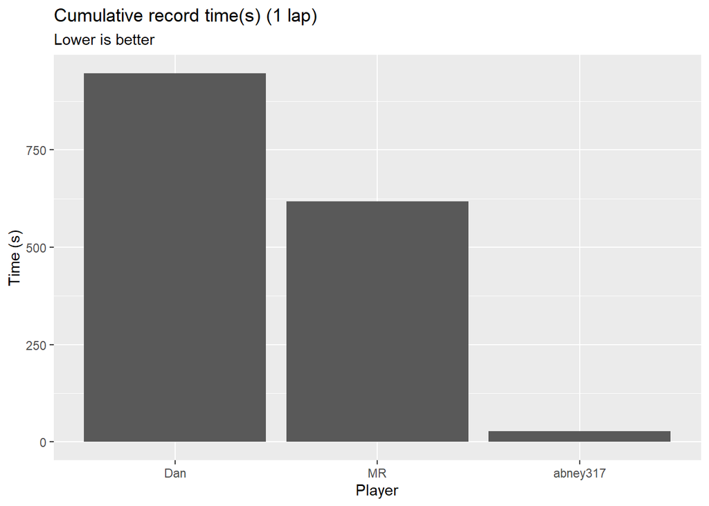

```r
lap_records %>%
  group_by(track, shortcut) %>%
  slice_min(time) %>%
  group_by(player) %>%
  summarise(sum_time_s = sum(time)) %>%
  ggplot(aes(x = fct_reorder(player, -sum_time_s), sum_time_s))+
  geom_col()+
  labs(title = "Cumulative record time(s) (1 lap)",
       subtitle = "Lower is better",
       y = "Time (s)",
       x = "Player")
```

The problem with a plots like this is that players that only have 1 record on the shortest stage in the game will look like they place higher. Mostly just using this as an idea of players to keep an eye on

> Total record duration

Again I will split between 3 laps and 1 lap

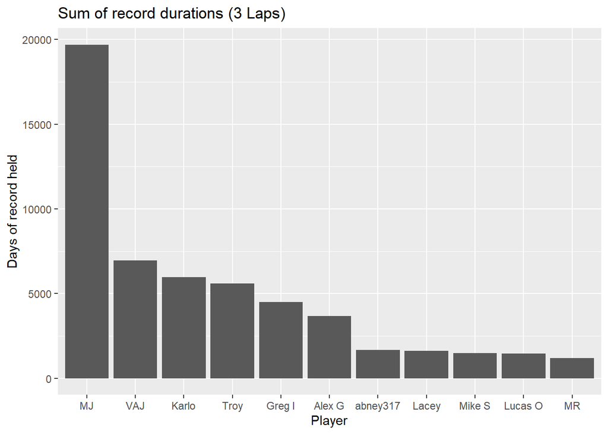

```r
course_records %>%
  group_by(track, shortcut) %>%
  slice_max(record_duration) %>% # Gets the highest record duration for each track
  group_by(player) %>% # Player who has that record
  summarise(total_record_days = sum(record_duration)) %>%
  ggplot(aes(x = fct_reorder(player, -total_record_days), total_record_days))+
  geom_col()+
  labs(title = "Sum of record durations (3 Laps)",
       x = "Player",
       y = "Days of record held")
```

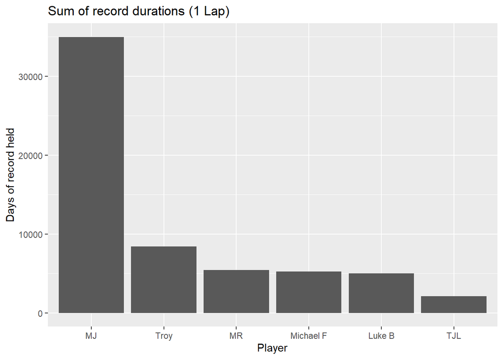

```r
lap_records %>%
  group_by(track, shortcut) %>%
  slice_max(record_duration) %>% # Gets the highest record duration for each track
  group_by(player) %>% # Player who has that record
  summarise(total_record_days = sum(record_duration)) %>%
  ggplot(aes(x = fct_reorder(player, -total_record_days), total_record_days))+
  geom_col()+
  labs(title = "Sum of record durations (1 Lap)",
       x = "Player",
       y = "Days of record held")
```

Graphing the number of longest records

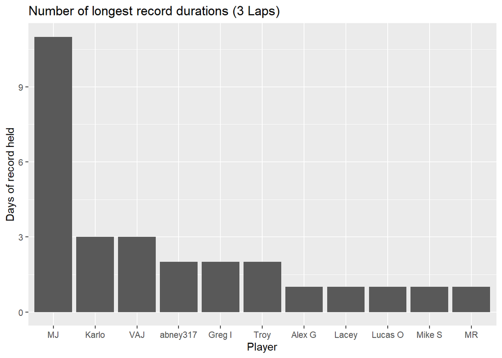

```r
course_records %>%
  group_by(track, shortcut) %>%
  slice_max(record_duration) %>% # Gets the highest record duration for each track
  group_by(player) %>% # Player who has that record
  summarise(n = n()) %>%
  ggplot(aes(x = fct_reorder(player, -n), n))+
  geom_col()+
  labs(title = "Number of longest record durations (3 Laps)",
       x = "Player",
       y = "Days of record held")
```

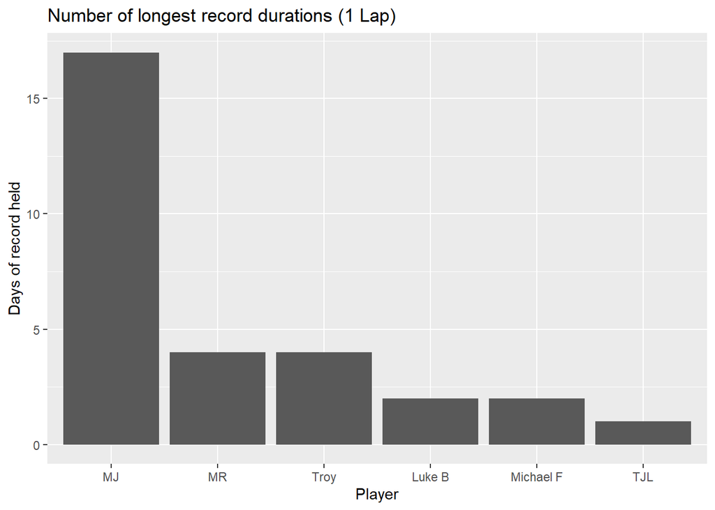

```r
lap_records %>%
  group_by(track, shortcut) %>%
  slice_max(record_duration) %>% # Gets the highest record duration for each track
  group_by(player) %>% # Player who has that record
  summarise(n = n()) %>%
  ggplot(aes(x = fct_reorder(player, -n), n))+
  geom_col()+
  labs(title = "Number of longest record durations (1 Lap)",
       x = "Player",
       y = "Days of record held")
```

Conclusions I came up with based on the data * Penev, One of the first to ever start speedrunning Mario Kart 64 but has not broken any records after the first few years * MJ and MR have shown up in almost all plots that I created so it might be safe to say that they have the biggest influence on the game